# English Premier League 2019/2020

Vicente Celis (viceron@alumni.uv.es)

Universitat de València

Diciembre de 2020 (actualizado el 05-01-2021)

Trabajo elaborado para la asignatura “Programación y manejo de datos en la era del Big Data” de la Universitat de València durante el curso 2020-2021. El repo del trabajo está [aquí](https://github.com/vicentecelisr/trabajo_BigData). La página web de la asignatura y los trabajos de mis compañeros pueden verse [aquí](https://perezp44.github.io/intro-ds-20-21-web/07-trabajos.html).

[figure not shown]

# 1. Introducción

Este trabajo se realiza con el fin de analizar las estadisticas de los equipos y jugadores de la primera division de la liga de Inglaterra. Considerada una de las 5 grandes ligas europeas que para muchos, sus 38 jornadas, la convierten en la mas competitiva y relevante del mundo, tambien gracias a su historia y a la participacion de tantos grandes clubes como Manchester United, Chelsea, Liverpool entre otros. Ilutraremos la tabla de clasificacion de cada equipo, el Campeon de la liga, los descensos a la segunda division y los equipos que alcanzaron las maximas competiciones europeas (Champions League y Europa League). Ademas estudiaremos los maximos goleadores de la temporada tanto por equipos como jugadores mediante la utilizacion de graficos ilustrativos. Por ultimo, conoceremos los estadios donde se juegan los partidos de esta maxima competicion, señalando varios aspectos interesantes que nos ayudaran a adentrarnos a un mas en esta grandiosa competicion inglesa.

## Datos

### **Fuente de los Datos**

Los datos fueron obtenidos de varias paginas como el diario Marca, Wikipedia y la pagina oficial de la Premier Leaguey luego fueron modificados por mi en un excel incluido en la carpeta datos. La manipulacion de los datos se realizaron gracias a los slides y tutoriales suministrados por el profesor de la materia Pedro Perez.

### **Codigos**

```r
clasif <- read_excel("./datos/premier-league.xlsx", sheet = 1)

max_gol <- read_excel("./datos/premier-league.xlsx", sheet = 2 )

asistencia <- read_excel("./datos/premier-league.xlsx", sheet = 3 )

premio <- read_excel("./datos/premier-league.xlsx", sheet = 4 )

clasif_1 <- clasif %>% filter(!(is.na(Clasif2021))) %>% select(Pos, Equipo, Pts, Clasif2021)

str(clasif_1)
```

```
#> tibble [10 x 4] (S3: tbl_df/tbl/data.frame)
#>  $ Pos       : num [1:10] 1 2 3 4 5 6 8 18 19 20
#>  $ Equipo    : chr [1:10] "Liverpool (C)" "Manchester City" "Manchester United" "Chelsea" ...
#>  $ Pts       : num [1:10] 99 81 66 66 62 59 56 34 34 21
#>  $ Clasif2021: chr [1:10] "Fase de grupos de la Liga de Campeones" "Fase de grupos de la Liga de Campeones" "Fase de grupos de la Liga de Campeones" "Fase de grupos de la Liga de Campeones" ...
```

```r
clasif_1 <- clasif_1 %>% mutate(Equipo = forcats::as_factor(Equipo))

str(clasif_1)
```

```
#> tibble [10 x 4] (S3: tbl_df/tbl/data.frame)
#>  $ Pos       : num [1:10] 1 2 3 4 5 6 8 18 19 20
#>  $ Equipo    : Factor w/ 10 levels "Liverpool (C)",..: 1 2 3 4 5 6 7 8 9 10
#>  $ Pts       : num [1:10] 99 81 66 66 62 59 56 34 34 21
#>  $ Clasif2021: chr [1:10] "Fase de grupos de la Liga de Campeones" "Fase de grupos de la Liga de Campeones" "Fase de grupos de la Liga de Campeones" "Fase de grupos de la Liga de Campeones" ...
```

```r
levels(clasif_1$Equipo)
```

```
#>  [1] "Liverpool (C)"     "Manchester City"   "Manchester United"
#>  [4] "Chelsea"           "Leicester City"    "Tottenham Hotspur"
#>  [7] "Arsenal"           "Bournemouth (R)"   "Watford (R)"
#> [10] "Norwich City (R)"
```

```r
clasif_1 <- clasif_1 %>% mutate(Equipo = forcats::fct_reorder(Equipo, Pts))

levels(clasif_1$Equipo)
```

```
#>  [1] "Norwich City (R)"  "Bournemouth (R)"   "Watford (R)"
#>  [4] "Arsenal"           "Tottenham Hotspur" "Leicester City"
#>  [7] "Manchester United" "Chelsea"           "Manchester City"
#> [10] "Liverpool (C)"
```

```r
top_gf <- clasif %>% select(Equipo, GF) %>% slice_max(GF, n = 5)

str(top_gf)
```

```
#> tibble [5 x 2] (S3: tbl_df/tbl/data.frame)
#>  $ Equipo: chr [1:5] "Manchester City" "Liverpool (C)" "Chelsea" "Leicester City" ...
#>  $ GF    : num [1:5] 102 85 69 67 66
```

```r
top_gf <- top_gf %>% mutate(Equipo = forcats::as_factor(Equipo))

str(top_gf)
```

```
#> tibble [5 x 2] (S3: tbl_df/tbl/data.frame)
#>  $ Equipo: Factor w/ 5 levels "Manchester City",..: 1 2 3 4 5
#>  $ GF    : num [1:5] 102 85 69 67 66
```

```r
levels(top_gf$Equipo)
```

```
#> [1] "Manchester City"   "Liverpool (C)"     "Chelsea"
#> [4] "Leicester City"    "Manchester United"
```

```r
top_gf <- top_gf %>% mutate(Equipo = forcats::fct_reorder(Equipo, GF))

levels(top_gf$Equipo)
```

```
#> [1] "Manchester United" "Leicester City"    "Chelsea"
#> [4] "Liverpool (C)"     "Manchester City"
```

```r
leaflet() %>% addTiles() %>% leafem::addMouseCoordinates()
```

[interactive chart not shown]

# 2. Tabla de la English Premier League Temporada 2019/2020

La temporada 2019/2020 fue un año muy singular y esto debido a la pandemia mundial que todos conocemos como lo fue el coronavirus. Esta situacion pandemica provoco la detencion de los partidos desde la jornada 28 del 1 de Marzo hasta el 17 de junio que se pudo reanudar. Sin embargo y pese a estos 3 meses de la falta de este gran futbol, dejo varios aspectos relevantes: lograr el Liverpool conseguir el titulo de campeon después de 30 años tras su última victoria y primero con la denominacion Premier League. Ademas haberlo conseguido rompiendo varios records como ser el primer equipo de la competición y de Europa que clasificó más anticipadamente a la fase de grupos de la Liga de Campeones de la UEFA (12 fechas de anticipación). Tambien cabe a destacar que introdujo por primera vez la tecnologia VAR (Video Arbitraje).

> “Es increíble ser campeón con este equipo. Ha sido muy fácil motivar a los jugadores por la gran historia que tiene el club. Es un logro increíble para mis jugadores, lo es todo lo que han hecho durante los últimos tres años”. Jürgen Klopp

| Pos | Equipo | Pts | PJ | G | E | P | GF | GC | Dif | Clasif2021 |
| --- | --- | --- | --- | --- | --- | --- | --- | --- | --- | --- |
| 1 | Liverpool (C) | 99 | 38 | 32 | 3 | 3 | 85 | 33 | 52 | Fase de grupos de la Liga de Campeones |
| 2 | Manchester City | 81 | 38 | 26 | 3 | 9 | 102 | 35 | 67 | Fase de grupos de la Liga de Campeones |
| 3 | Manchester United | 66 | 38 | 18 | 12 | 8 | 66 | 36 | 30 | Fase de grupos de la Liga de Campeones |
| 4 | Chelsea | 66 | 38 | 20 | 6 | 12 | 69 | 54 | 15 | Fase de grupos de la Liga de Campeones |
| 5 | Leicester City | 62 | 38 | 18 | 8 | 12 | 67 | 41 | 26 | Fase de grupos de la Liga Europa |
| 6 | Tottenham Hotspur | 59 | 38 | 16 | 11 | 11 | 61 | 47 | 14 | Segunda ronda de la Liga Europa |
| 7 | Wolverhampton Wanderers | 59 | 38 | 15 | 14 | 9 | 51 | 40 | 11 | NA |
| 8 | Arsenal | 56 | 38 | 14 | 14 | 10 | 56 | 48 | 8 | Fase de grupos de la Liga Europa |
| 9 | Sheffield United | 54 | 38 | 14 | 12 | 12 | 39 | 39 | 0 | NA |
| 10 | Burnley | 54 | 38 | 15 | 9 | 14 | 43 | 50 | -7 | NA |
| 11 | Southampton | 52 | 38 | 15 | 7 | 16 | 51 | 60 | -9 | NA |
| 12 | Everton | 49 | 38 | 13 | 10 | 15 | 44 | 56 | -12 | NA |
| 13 | Newcastle United | 44 | 38 | 11 | 11 | 16 | 38 | 58 | -20 | NA |
| 14 | Crystal Palace | 43 | 38 | 11 | 10 | 17 | 31 | 50 | -19 | NA |
| 15 | Brighton & Hove Albion | 41 | 38 | 9 | 14 | 15 | 39 | 54 | -15 | NA |
| 16 | West Ham United | 39 | 38 | 10 | 9 | 19 | 49 | 62 | -13 | NA |
| 17 | Aston Villa | 35 | 38 | 9 | 8 | 21 | 41 | 67 | -26 | NA |
| 18 | Bournemouth (R) | 34 | 38 | 9 | 7 | 22 | 40 | 65 | -25 | Descenso de Categoria |
| 19 | Watford (R) | 34 | 38 | 8 | 10 | 20 | 36 | 64 | -28 | Descenso de Categoria |
| 20 | Norwich City (R) | 21 | 38 | 5 | 6 | 27 | 26 | 75 | -49 | Descenso de Categoria |

### Una forma de visualizar los puntos obtenidos en la liga

[interactive chart not shown]

[figure not shown]

# 3. Analisis Clasificacion Siguiente Temporada

## Competiciones Europeas y Descenso de Categoria

En esta grafica podemos observar la clasificacon a competiciones europeas de los primeros clasificados en la tabla y sus respectivos puntos onseguidos, los primeros 4 puestos clasifican a la Champions League y los 5 y 6 lugar a la Europa Legue. Podemos destacar la actuacion del Arsenal que al haber ganado la FA Cup tuvo como premio formar parte de la Europa League. Por ultimo, observamos los 3 equipos con menos puntos (Watford, Bournemouth y Norwich City) que jugaran la proxima temporada 20/21 en la segunda division de inglaterra (EFL Championship).

### **Grafico 1**

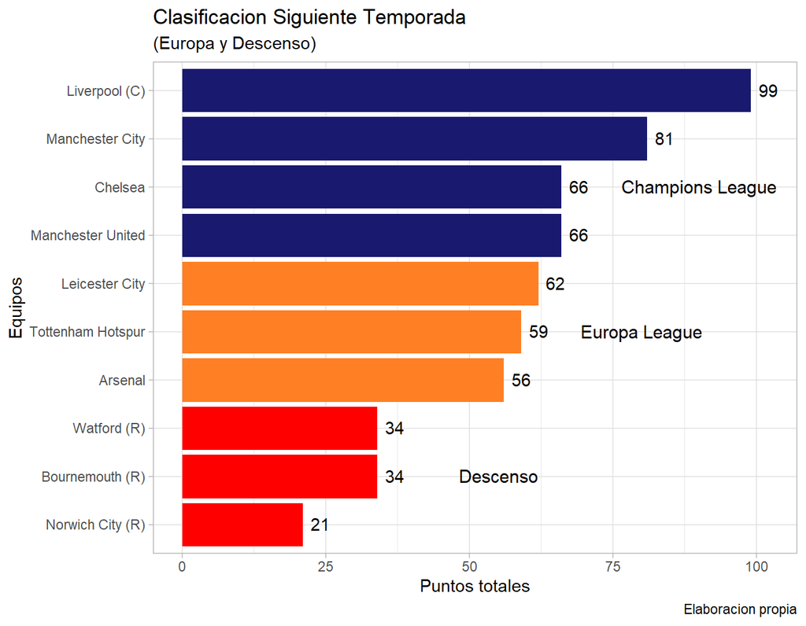

### **Grafico 2**

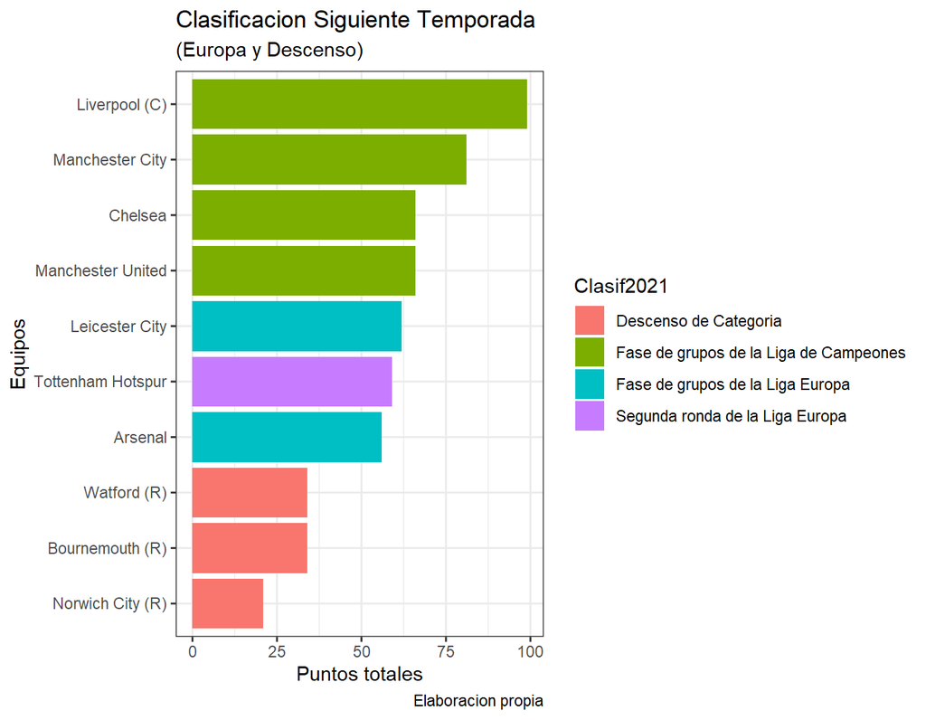

# 4. Analisis Goles Anotados

## Equipos con mas Goles Anotados

### **Grafico 3**

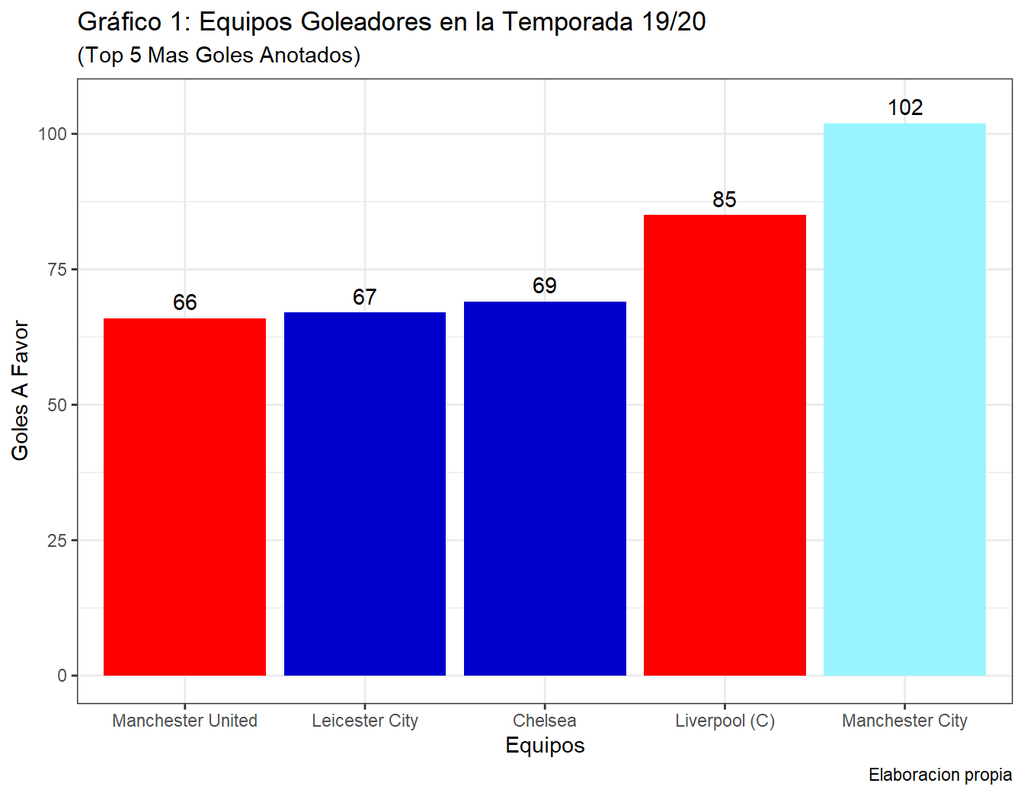

### **Grafico 4**

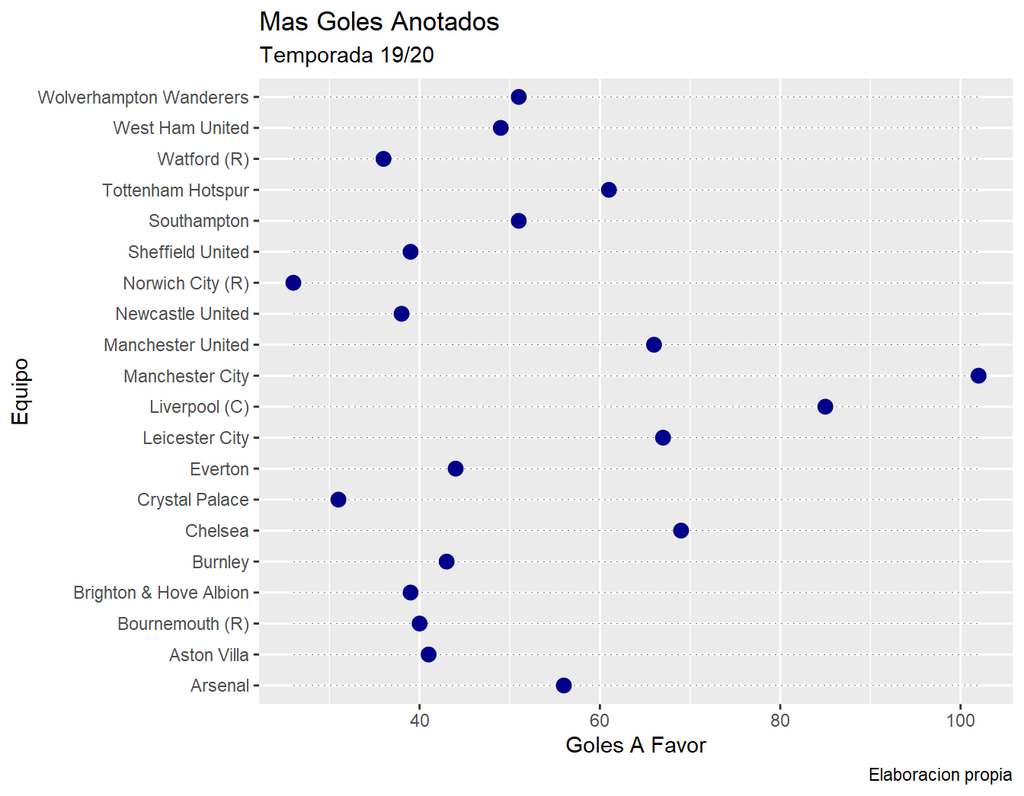

## Los Pichichis (Jugadores con mas goles en la temporada)

[figure not shown]

En esta tabla podemos observar a los maximos anotadores y las estadisticas de cada jugador respecto a los partidos y minutos jugados en todos los partidos de la temporada. En el como maximo goleador aparece el jugador ingles Jamie Vardy (Leicester City) con 23 dianas, seguido de un empate en goles y terminando el podio el jugador gabones Pierre-Emerick Aubameyang (Arsenal) y el jugador ingles Danny Ings (Southampton).

| jugador | goles | partidosjugados | Promediogpp | minutosjugados | minutopgol | Club |
| --- | --- | --- | --- | --- | --- | --- |
| Jamie Vardy | [23](https://www.premierleague.com/stats/top/players/goals?se=274) | 35 | 0.66 | 3034 | 132 | Leicester City |
| Pierre-Emerick Aubameyang | [22](https://www.premierleague.com/stats/top/players/goals?se=274) | 36 | 0.61 | 3138 | 143 | Arsenal |
| Danny Ings | [22](https://www.premierleague.com/stats/top/players/goals?se=274) | 38 | 0.58 | 2812 | 128 | Southampton |
| Raheem Sterling | [20](https://www.premierleague.com/stats/top/players/goals?se=274) | 33 | 0.61 | 2660 | 133 | Manchester City |
| Mohamed Salah | [19](https://www.premierleague.com/stats/top/players/goals?se=274) | 34 | 0.56 | 2884 | 152 | Liverpool |
| Harry Kane | [18](https://www.premierleague.com/stats/top/players/goals?se=274) | 29 | 0.62 | 2589 | 144 | Tottenham |
| Sadio Mané | [18](https://www.premierleague.com/stats/top/players/goals?se=274) | 35 | 0.51 | 2753 | 153 | Liverpool |
| Marcus Rashford | [17](https://www.premierleague.com/stats/top/players/goals?se=274) | 31 | 0.55 | 2653 | 156 | Manchester United |
| Anthony Martial | [17](https://www.premierleague.com/stats/top/players/goals?se=274) | 32 | 0.53 | 2638 | 155 | Manchester United |
| Raúl Jiménez | [17](https://www.premierleague.com/stats/top/players/goals?se=274) | 38 | 0.45 | 3244 | 191 | Wolverhampton |

### Otra forma de visualizar los goleadores de la temporada

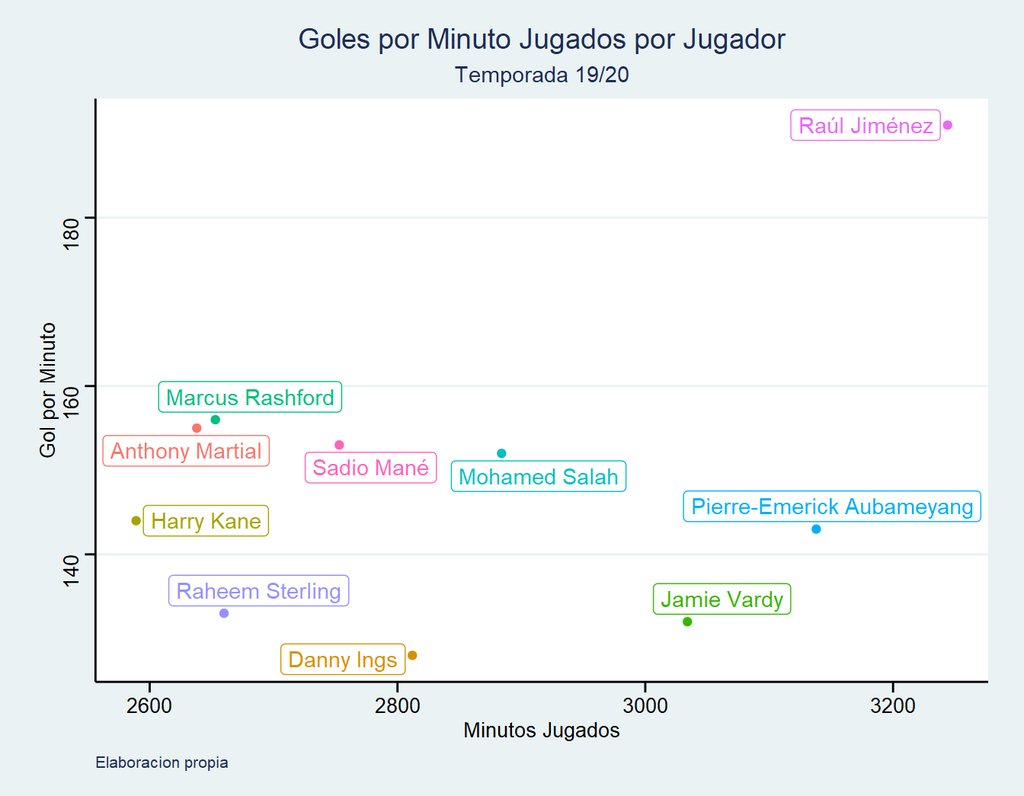

[video not shown]

# 5. Analisis Asistencias

El maximo asistidor y con mucha diferencia es el futbolista belga Kevin De Bruyne con unas 20 asistencias seguido de 3 jugadores del club campeon el Liverpool los cuales son Trent Alexander-Arnold, Andrew Robertson y Mohamed Salah. El jugador belga considerado el mejor mediocampista ofensivo de la epoca ha sido premiado con el premio playmaker en la liga que es el nuevo premio que entregará la Premier League para reconocer al mejor orquestador de la temporada.

> “Me siento bien. Significa que he hecho un buen trabajo. Soy un creador y trato de crear oportunidades para mis compañeros de equipo. Si anotan, obtengo la asistencia y me veo bien” Kevin De Bruyne.

**Maximos Asistidores**

**Temporada 2019/2020**

| Jugador | asistencias | nacionalidad |
| --- | --- | --- |
| Kevin De Bruyne | 20 |  |
| Trent Alexander-Arnold | 13 |  |
| Andrew Robertson | 12 |  |
| Mohamed Salah | 10 |  |
| David Silva | 10 |  |
| Heung-min Son | 10 |  |
| Riyad Mahrez | 9 |  |
| Adama Traoré | 9 |  |
| Harvey Barnes | 8 |  |
| Roberto Firmino | 8 |  |

# 6. Premios en la Temporada

Los mas galardonados de la temporada, ya mencionado anteriormente, sin duda alguna el mas destacado, el futbolista kevin De Bruyne fue el MVP mejor jugador de la temporada y recibio el premio playmaker al mejor armador de juego en la temporada. Tambien podemos destacar el gol de la temporada anotado por el coreano Heugh-Min Son que lo podemos ver luego de la tabla. La bota de Oro para el mayor anotador mencionado antes Jamie Vardy. mejor jugador mas joven o golden boy de la temporada se lo lleva el jugador del Liverpool Alexander-Arnold. Tambien vemos premios como al mejor manager Jurguen Klopp y el guante de oro para el portero del Manchester City Ederson.

| Premio | Premiado | Equipo |
| --- | --- | --- |
| Player of the Season | [Kevin De Bruyne](https://www.tudn.com/futbol/premier-league/jurgen-klopp-y-kevin-de-bruyne-son-el-mejor-tecnico-y-jugador-de-la-premier-league) | Manchester City |
| Goal of the Season | [Son Heung-Min](https://www.tudn.com/futbol/premier-league/jurgen-klopp-y-kevin-de-bruyne-son-el-mejor-tecnico-y-jugador-de-la-premier-league) | Tottenham Hotspur |
| Manager of the Season | [Jürgen Klopp](https://www.tudn.com/futbol/premier-league/jurgen-klopp-y-kevin-de-bruyne-son-el-mejor-tecnico-y-jugador-de-la-premier-league) | Liverpool |
| Young Player of the Season | [Trent Alexander-Arnold](https://www.tudn.com/futbol/premier-league/jurgen-klopp-y-kevin-de-bruyne-son-el-mejor-tecnico-y-jugador-de-la-premier-league) | Liverpool |
| Golden Boot | [Jamie Vardy](https://www.tudn.com/futbol/premier-league/jurgen-klopp-y-kevin-de-bruyne-son-el-mejor-tecnico-y-jugador-de-la-premier-league) | Leicester City |
| Golden Glove | [Ederson](https://www.tudn.com/futbol/premier-league/jurgen-klopp-y-kevin-de-bruyne-son-el-mejor-tecnico-y-jugador-de-la-premier-league) | Manchester City |
| Playmaker | [Kevin De Bruyne](https://www.tudn.com/futbol/premier-league/jurgen-klopp-y-kevin-de-bruyne-son-el-mejor-tecnico-y-jugador-de-la-premier-league) | Manchester City |

[video not shown]

# 7. Estadios de los Equipos de Primera Division Temporada 19/20

Para complementar este analisis conoceremos los estadios de los 20 equipos que se dejaron la piel este año combatiendo partido a partido en estos grandes campos de juego. Nos encontramos con la ubicacion de cada uno de los campos en las distintas ciudades de Inglaterra. Como dato interesante la distancia mas larga recorrida entre dos equipos es de 568 kilometros, que es la distancia que tienen que recorrer los equipos New Castle United y Bournemouth para sus respectivos enfrentamientos. Ademas podemos destacar la ciudad de Liverpool donde los estadios del Liverpool y el Everton los separa una distancia solo de 1,9 kilometros. Por ultimo podemos observar que en la ciudad de Londres se encuentran 5 equipos los cuales son: West Ham United, Chelsea, Tottenham, Arsenal y el Crystal Palace.

[interactive chart not shown]

# 8. Conclusión